# Guide to using *conduit*

Ashley Noel Hinton

The *openapi* project is an attempt to make it easier to connect people with data. The *openapi* architecture uses an XML scheme to describe modules of discrete data analaysis and exploration steps, which can be arranged in pipelines to describe data workflows. Both modules and pipelines can be shared, modified, and rearranged to suit the user’s requirements. Modules and pipelines are exected in an *openapi* glue system. *conduit* is a prototype glue system which has been written as a package for the R programming environment. More information on the *openapi* project can be found in the University of Auckland Department of Statistics technical report, [Introducing OpenAPI](https://www.stat.auckland.ac.nz/~paul/Reports/openapi/introducingOpenapi/introducingOpenapi.html).

## Quick start: running a pipeline

### Installing *conduit*

*conduit* is an R package built using R version 3.1.x on a 64-bit Linux machine. It requires the following R packages: [*XML*](http://www.omegahat.org/RSXML), [*graph*](http://bioconductor.org/packages/release/bioc/html/graph.html), [*RBGL*](http://bioconductor.org/packages/release/bioc/html/RBGL.html), and [*RCurl*](http://www.omegahat.org/RCurl). The [*devtools*](http://cran.r-project.org/web/packages/devtools/index.html) is required to install *conduit* directly from github. The [*Rgraphviz*](http://bioconductor.org/packages/release/bioc/html/Rgraphviz.html) and [*gridGraphviz*](http://r-forge.r-project.org/R/?group_id=1272) packages are required to run the modules in this quick start example.

Version 0.1 of the *conduit*, built 2015-02-08, is available for download.

Source code for *conduit* is available at https://github.com/anhinton/conduit for those who would like to build and install the package manually.

To install *conduit* using *devtools*:

```r
install.packages("devtools")
devtools::install_github("anhinton/conduit")
```

Load the *conduit* package:

```r
library(conduit)
```

### Reading a pipeline from an XML file

The `loadPipeline()` function is used to read a pipeline XML file into *conduit*. `loadPipeline()` requires a `name` argument, and a `ref` argument which describes the XML file location The function returns a `pipeline` object.

We will load a pipeline which creates and plots a simple node-and-edge graph. oThe pipeline XML file is in a sub-directory of the R working directory called ‘simpleGraph’.

```r
## load the simpleGraph pipeline
simpleGraph <-
    loadPipeline(name = "simpleGraph", ref="simpleGraph/pipeline.xml")
```

According to its `description`:

```
This pipeline creates a directed graphNEL graph, lays it out using the Rgraphviz package, and then plots the graph as a PNG file using the gridGraphviz package
```

### Run a pipeline in *conduit*

The `runPipeline()` function is used to run a `pipeline` object in R. It requires a `pipeline` object as its only argument. This function will create a directory for the pipeline in the ‘pipelines’ sub-directory of the current working directory. If a ‘pipelines’ sub-directory does not exist it will be created. Each module in the pipeline will create output in a named directory found in ./pipelines/PIPELINE_NAME/modules.

```r
## run the simpleGraph pipeline
runPipeline(simpleGraph)
```

This creates the following files:

1. pipelines/simpleGraph/modules/createGraph/directedGraph.rds
2. pipelines/simpleGraph/modules/createGraph/script.R
3. pipelines/simpleGraph/modules/layoutGraph/Ragraph.rds
4. pipelines/simpleGraph/modules/layoutGraph/script.R
5. pipelines/simpleGraph/modules/plotGraph/example.png
6. pipelines/simpleGraph/modules/plotGraph/script.R

File number 5, pipelines/simpleGraph/modules/plotGraph/example.png is the output file we require, the PNG image of the graph. The image is shown below:

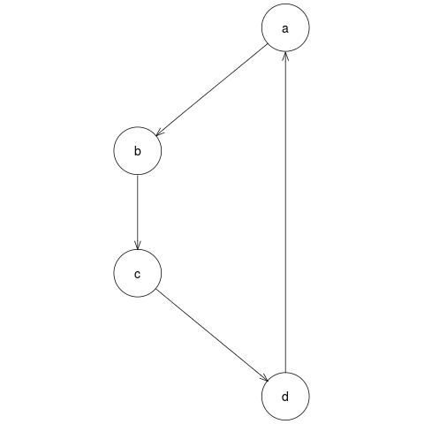

## Modules

This sections describes how to: load modules from XML files; create modules; execute module source scripts; save modules as module XML files.

### Loading modules from XML

#### `loadModule()`

This function reads and interprets a module XML file, producing a `module` object in R. It requires the following arguments:

- `name`: module name (must be unique within a pipeline)
- `ref`: Filename or file path of xml file.
  - `path`: optional search path(s) for `ref` resource

`loadModule()` also accepts a `namespaces` argument, which should be a named character vector of namespaces used in the module XML file. The default value for `namespaces` is `c(oa = "http://www.openapi.org/2014/"))`.

Example:

```r
plotGraphXML <- file.path("simpleGraph", "plotGraph.xml")
plotGraph <- loadModule(name = "plotGraph",
                        ref = plotGraphXML)
```

### Creating modules

Modules can be created in *conduit* using the `module()` function and its associated helper functions. The resulting modules can be executed in *conduit*, or saved to disk as module XML files.

The following example shows how a module can be created.

```r
## create input, output, and source lists
inputsList <-
    list(moduleInput("myGraph", "internal", "R \"graphNEL\" object"))
outputsList <-
    list(moduleOutput("Ragraph", "internal", "R \"Ragraph\" object"))
sourcesList <-
    list(moduleSource(value = c("library(Rgraphviz)",
                                "Ragraph <- agopen(myGraph, \"myGraph\")")))
## create module
layoutGraph <- module(name = "layoutGraph", platform = "R",
                      description = "Lays out a graphNEL graph using the Rgraphviz package",
                      inputs = inputsList,
                      outputs = outputsList,
                      sources = sourcesList)
```

#### `module()`

The `module()` function is used to create module objects.

Required aruments:

- `name`: module name (must be unique within a pipeline)
- `platform`: name of platform required to execute module source

Optional arguments:

- `description`: a brief description of what the module does
- `inputs`: a list of `moduleInput` objects
- `outputs`: a list of `moduleOutput` objects
- `sources`: a list of `moduleSource` objects

Examples:

```r
mod1 <- module(name = "cleanCSV", platform = "R",
               description = "clean up the data in a CSV file",
               inputs = inputsList1, outputs = outputsList1,
               sources = sourcesList1)
```

#### `moduleInput()`

The `moduleInput()` function is used to create the inputs for modules created in R with the `module()` function. Each input should correspond to an object of the same name in the module’s source(s). It requires the following arguments:

- `name`: input name (must be unique within a module)
- `type`: “internal” or “external”

Optional arguments:

- `format`: format of input for validation, e.g. “R data frame”
- `formatType`: type of object given to be used for validation. Defaults to “text” to perform text-matching of `format`s.

Examples:

```r
inp1 <- moduleInput(name = "pollingBooths", type = "internal",
                    format = "R data frame")
inp2 <- moduleInput(name = "boothLatLong", type = "external",
                    format = "CSV file", formatType = "text")
```

#### `moduleOutput()`

The `moduleOutput()` function is used to create the outputs for modules created in R with the `module()` function. Each “internal” output should correspond to an object of the same name in the module’s source(s). “external” outputs are not produced by *conduit*, but are produced directly by the module source script(s). It is recommended that an “external” output have the same `name` and `ref`, though this is not compulsory. `moduleOutput()` requires the following arguments:

- `name`: output name (must be unique within a module)
- `type`: “internal” or “external”
  - `ref`: if the output `type` is “external” a `ref` must be provided. This provides the file location of the external output produced by the module source(s). This should be either a filename if the source(s) produce the file in the working direcory, or the full resource location of the external file. Relative file paths should not be used.

Optional arguments:

- `format`: format of input for validation, e.g. “R data frame”
- `formatType`: type of object given to be used for validation. Defaults to “text” to perform text-matching of `format`s.

Examples:

```r
outp1 <- moduleOutput(name = "pollingBooths", type = "internal",
                      format = "R data frame")
outp2 <- moduleOutput(name = "boothCoords.csv", type = "external",
                      format = "CSV file", ref = "boothCoords.csv")
```

#### `moduleSource()`

The `moduleSource()` function creates source objects. These objects contain the scripts which are to be executed using a module’s platform.

A source script can either be provided inline as a character vector, or as a reference to a script file.

Arguments:

- `value`: a character vector containing the script to be executed. If `value` argument is empty, and a `ref` is provided, script will be read from the resource provided in `ref`.
- `ref`: Filename or file location of a text script file.
  - `path`: optional search path(s) for `ref` resource
- `type`: not used as at 2015-01-07.
- `order`: numeric value specifying the position of execution of this source in the module’s sources. Module sources are executed in the following order:
  1. negative numbers in ascending order
  2. 0 (zero)
  3. no order specified
  4. positive numbers in ascending order

Examples:

```r
script1 <- "pollingPlaces <- read.csv(file = csv_input)"
source1 <- moduleSource(value = script1)
source2 <- moduleSource(ref = "plotting.R", path = "~/handyScripts",
                        order = "-1")
```

### Executing module scripts

#### `runModule()`

Module source scripts are executed using the `runModule()` function. The function makes the module’s inputs available to the source script(s) in the designated platform, and executes the source script(s). The module’s outputs are saved to a directory called `modules`, in a subdirectory with the module’s name. This function requires the following arguments:

- `module`: a module object, usually from `module()` or `loadModule()`
- `inputs`: a named list of absolute locations of module’s inputs
- `targetDirectory`: file path for `modules` output directory

Examples:

```r
## run a module with no inputs
createGraphXML <- file.path("simpleGraph", "createGraph.xml")
createGraph <- loadModule(name = "createGraph", ref = createGraphXML)
runModule(module = createGraph, targetDirectory = getwd())
```

The module’s output can be found at:

- directedGraph.rds

```r
## run a module with an input
layoutGraphXML <- file.path("simpleGraph", "layoutGraph.xml")
layoutGraph <- loadModule("layoutGraph", layoutGraphXML)
## this module uses the output from the previous module as input
myGraph <- file.path("modules", "createGraph", "directedGraph.rds")
runModule(module = layoutGraph,
          inputs = c(myGraph = normalizePath(myGraph)))
```

### Saving modules as XML files

#### `saveModule()`

This function saves a module to disk as a module XML file. This function requires a `module` object be passed to the `module` argument. The function also accepts the following optional arguments:

- `targetDirectory`: location to save XML file. This defaults to the current working directory.
- `filename`: name of resulting XML file. If not specified the file will be given the `module` name with ‘.xml’ appended.

The full path of the resulting file is returned.

Examples:

Specify the filename for the new module XML file:

```r
createGraph <- loadModule("createGraph",
                          file.path("simpleGraph", "createGraph.xml"))
tempTarget <- tempdir()
saveModule(module = createGraph, targetDirectory = tempTarget,
           filename = "newCreateGraph.xml")
```

```
## [1] "/tmp/RtmpjtBjkk/newCreateGraph.xml"
```

Save a module to XML without specifiying the filename:

```r
layoutGraph <- loadModule("layoutGraph",
                          file.path("simpleGraph", "layoutGraph.xml"))
layoutGraph$name
```

```
## [1] "layoutGraph"
```

```r
saveModule(module = layoutGraph, targetDirectory = tempTarget)
```

```
## [1] "/tmp/RtmpjtBjkk/layoutGraph.xml"
```

## Pipelines

This sections describes how to: load pipelines from XML files; create pipelines ; execute pipeline components; save pipelines and their components as XML files.

### Loading pipelines from XML

#### `loadPipeline()`

This function reads and interprets a pipeline XML file, producing a `pipeline` object in R. The function will also read and interpret module and pipeline XML provided in the XML’s file `<component>` nodes. The resulting objects will be loaded into the `components` slot of the parent `pipeline` object. `loadPipeline()` requires the following arguments:

- `name`: pipeline name
- `ref`: Filename or file path of XML file.
  - `path`: optional search path(s) for `ref` resource

`loadPipeline()` also accepts a `namespaces` argument, which should be a named character vector of namespaces used in the pipeline XML file. The default value for `namespaces` is `c(oa = "http://www.openapi.org/2014/"))`.

Example:

```r
simpleGraph <- loadPipeline(name = "simpleGraph",
                            ref = file.path("simpleGraph", "pipeline.xml"))
```

### Creating pipelines

Pipelines can be created using the `pipeline()` function, and its associated helper functions. The resulting `pipeline` objects can be executed using *conduit*, or saved to disk as XML files.

#### `pipeline()`

The `pipeline` function requires a `name` argument. The following arguments can also be provided:

- `description`: A text description of what the pipeline does.
- `components`: a list of the pipelines components. These must be `module` or `pipeline` objects (or both). If this argument is empty the pipeline’s components will be taken from the following arguments:
  - `modules`: a list of `module` objects.
  - `pipelines`: a list of `pipeline` objects.
- `pipes`: a list of `pipe` objects.

Example:

```r
createGraph <- loadModule("createGraph",
                          file.path("simpleGraph", "createGraph.xml"))
layoutGraph <- loadModule("layoutGraph",
                          file.path("simpleGraph", "layoutGraph.xml"))
pipe1 <- pipe("createGraph", "directedGraph", "layoutGraph", "myGraph")
pipelineExample <-
    pipeline(name = "example",
             components = list(createGraph, layoutGraph),
             pipes = list(pipe1))
```

#### `addComponent()`

`addComponent` can be used to add a `module` or `pipeline` to the components of a `pipeline` created created with `pipeline()` or `loadPipeline()`.

Arguments:

- `newComponent`: `module` or `pipeline` object to be added.
- `pipeline`: pipeline to be amended.

Example:

```r
testPipeline <- pipeline("test")
plotGraph <- loadModule("plotGraph",
                        file.path("simpleGraph", "plotGraph.xml"))
testPipeline <- addComponent(plotGraph, testPipeline)
```

#### `pipe()`

This function creates a `pipe` object, which connects the output of one pipeline component to the input of another pipeline component. The function requirtes four character vectors as arguments:

- `startComponent`: name of the start component.
- `startOutput`: name of the required start component output.
- `endComponent`: name of the end component.
- `endInput`: name of the requrired end component input.

Example:

```r
pipe1 <- pipe(startComponent = "createGraph", startOutput = "myGraph",
              endComponent = "layoutGraph", endInput = "directedGraph")
```

#### `addPipe()`

`addPipe()` can be used to add a new pipe to an existing `pipeline` object.

Arguments:

- `newPipe`: new `pipe` object.
- `pipeleine`: existing `pipeline` object.

Example:

```r
createGraph <- loadModule("createGraph",
                          file.path("simpleGraph", "createGraph.xml"))
layoutGraph <- loadModule("layoutGraph",
                          file.path("simpleGraph", "layoutGraph.xml"))
pipelineExample <-
    pipeline(name = "example",
             components = list(createGraph, layoutGraph))
## create new pipe
pipe1 <- pipe("createGraph", "directedGraph", "layoutGraph", "myGraph")
## add pipe to pipeline
pipelineExample <- addPipe(pipe1, pipelineExample)
```

### Executing pipeline components

#### `runPipeline()`

Pipeline can be executed using the `runPipeline()` function. The pipeline’s components will be executed in an order which ensures each component’s inputs will be satisfied. This function creates a directory called ‘pipelines’ in the current working directory. The output from a pipeline’s components are saved in this diretory, in a sub-directory named after the pipeline.

This function has one argument, `pipeline`, which must be a pipeline object created using `pipeline()` or `loadPipeline()`.

Example:

```r
simpleGraph <- loadPipeline("simpleGraph",
                            file.path("simpleGraph", "pipeline.xml"))
runPipeline(simpleGraph)
```

#### `runComponent()`

Individual components in a pipeline can be executed using the `runComponent()` function. This can be useful for testing a pipeline. This function requires two arguments:

- `componentName`: Name of component to be executed.
- `pipeline`: `pipeline` containing component.

If the component is a module with one or more inputs, these massed be provided as a named list to the `inputs` argument.

`runComponent()` will place component output in either a ‘modules’ or ‘pipelines’ directory, depending on the type of component. The location of this output directory can be specified using the `pipelinePath` argument.

Examples:

Running a component with no inputs:

```r
simpleGraph <- loadPipeline("simpleGraph",
                            file.path("simpleGraph", "pipeline.xml"))
names(simpleGraph$components)
```

```
## [1] "createGraph" "layoutGraph" "plotGraph"
```

```r
runComponent(componentName = "createGraph", pipeline = simpleGraph)
```

```
## [1] 0
```

The component’s output can be found at:

- directedGraph.rds

Running a component with one input:

```r
simpleGraph <- loadPipeline("simpleGraph",
                            file.path("simpleGraph", "pipeline.xml"))
runComponent("layoutGraph", simpleGraph,
             inputs =
                 list(myGraph =
                          normalizePath(
                              file.path("modules", "createGraph",
                                        "directedGraph.rds"))))
```

```
## [1] 0
```

The component’s output can be found at:

- Ragraph.rds

### Saving and exporting pipelines as XML files

Pipelines created using can `pipeline()` and `loadPipeline()` can be saved to disk as XML files using the `savePipeline()` and `exportPipeline()` functions. `savePipeline()` will produce a single XML representing the pipeline; `exportPipeline()` will also create an XML file for each of the pipeline’s components.

#### `savePipeline()`

A pipeline can be saved to an XML file using `savePipeline()`. The `pipeline` argument must be provided with a `pipeline` object. The resulting xml file is always called `pipeline.xml`. The location of this file can be set using the `targetDirectory` argument.

Example:

```r
simpleGraph <- loadPipeline("simpleGraph",
                            file.path("simpleGraph", "pipeline.xml"))
savePipeline(pipeline = simpleGraph, targetDirectory = "savePipeline")
```

```
## [1] "savePipeline/pipeline.xml"
```

The resulting XML file can be found at:

- pipeline.xml

#### `exportPipeline()`

`exportPipeline()` will save a pipeline to XML file, and save all its components to XML files, also. All the pipelines components will be given as references to the XML files created.

This function will save the XML files to a directory with pipeline’s name, in the location specified in the argument `targetDirectory`.

Example:

```r
simpleGraph <- loadPipeline("graphExport",
                            file.path("simpleGraph", "pipeline.xml"))
exportPipeline(pipeline = simpleGraph, targetDirectory = "exportPipeline")
```

```
## $pipeline
## [1] "exportPipeline/graphExport/pipeline.xml"
##
## $createGraph
## [1] "exportPipeline/graphExport/createGraph.xml"
##
## $layoutGraph
## [1] "exportPipeline/graphExport/layoutGraph.xml"
##
## $plotGraph
## [1] "exportPipeline/graphExport/plotGraph.xml"
```

The resulting XML files can be found at:

- pipeline.xml
- plotGraph.xml
- createGraph.xml
- layoutGraph.xml

## Searching for files in *conduit*

*conduit* allows the user to either specify the location of a resource file, or to provide a filename and file location(s) where the file should be found. Functions which have `ref` and `path` arguments provide the option to search for a resource.

If no resource can be sensibly found at `ref`, a search is started. *Conduit* will search by default in the directory for the module or pipeline which initiated the search, then R’s current working directory. The default search paths can be amended or replaced by the `path` argument. Search paths are given as character strings, with each path divided by the ‘|’ character. Values for `path` which end in ‘|’ will be prepended to the default search paths, and those which beging with ‘|’ will be appended.

*conduit* will search in each search path provided until a matching file is located. The first match will be returned.

The following example will attemp to load a module by searching for a file named in `ref` in the paths listed in `path`, and then the default search paths.

```r
mod1 <- loadModule(name = "loader", ref = "arrangeLines.xml",
                   path = "~/openapi|/media/ashley/floppyDisk|")
```

## Outputs in *conduit*

When a module’s source code is executed in *conduit* by the `runModule()` function, the module’s outputs are saved to disk in a directory with the same name as the module.

Internal outputs are saved to disk by serializing objects in a file format relevant to the platform used. For example, imagine a module source script for the “R” platform creates an object, `finalData.df`. To mark this object as a module output the module must contain an internal output, named “finalData.df”. When the module’s source script is executed *conduit* will produce a file named “finalData.df.rds” in the module’s output directory; the file extension “.rds” is used for serializing R objects. Similarly, internal outputs from source scripts for the “python” platform will be serialized to a file with the file extension “.pickle”.

External outputs should be easy to identify, as they will be explicitly named in the module’s source script.

## Example: creating a pipeline from R scripts

### R scripts

The R scripts for our example are as follows:

- createGraph.R:

```
## library(graph)
## nodes <- c("a", "b", "c", "d")
## edgeList <- list(a=list(edges=c("b")),
##                  b=list(edges=c("c")),
##                  c=list(edges=c("d")),
##                  d=list(edges=c("a")))
## directedGraph <- new("graphNEL", nodes=nodes, edgeL=edgeList,
##                      edgemode="directed")
```

- layoutGraph.R:

```
## library(Rgraphviz)
## Ragraph <- agopen(myGraph, "myGraph")
```

- plotGraph.R:

```
## library(gridGraphviz)
## png("example.png")
## grid.graph(Ragraph, newpage=TRUE)
## dev.off()
```

R users will notice that the second script calls for a “graphNEL” object `myGraph`, but that no such object has been created in the preceding scripts. This object will be named as an input of the second module, and will be made available to the module’s R script by the glue system. The object `Ragraph` in the third script will also be named as an nput for the third module.

### Creating the first module: `createGraph`

The first module has one source script, from the file createGraph.R:

```r
createGraphSource <- moduleSource(ref = file.path("example1", "scripts",
                                                  "createGraph.R"))
```

The source script creates an ’R “graphNEL” object, `directedGraph`, which we will name as an internal output:

```r
createGraphOutput <- moduleOutput(name = "directedGraph",
                                  type = "internal",
                                  format = "R \"graphNEL\" object")
```

Now we can create a module object, `createGraph`, with the name, “createGraph”, a description, and the source and output created above:

```r
createGraph <-
    module(name = "createGraph",
           platform = "R",
           description = "Create a simple directed graphNEL graph object with four nodes and four edges",
           sources =
               list(createGraphSource),
           outputs =
               list(createGraphOutput))
```

### The second module: `layoutGraph`

As mentioned above, our second module script requires a “graphNEL” object, `myGraph`. We will create our module with an internal input called `myGraph` which *conduit* will use to provide this module with its required object:

```r
layoutGraphInput <- moduleInput(name = "myGraph",
                                type = "internal",
                                format = "R \"graphNEL\" object")
```

This module has one source, from the file layoutGraph.R, which produces an “Ragraph” object, `Ragraph`. We will name `Ragraph` as an output. We create the module with the following code:

```r
layoutGraph <-
    module(name = "layoutGraph",
           platform = "R",
           description = "Lays out a graphNEL graph using the Rgraphviz package",
           inputs = list(layoutGraphInput),
           sources = list(moduleSource(ref = file.path("example1", "scripts",
                                                       "layoutGraph.R"))),
           outputs = list(moduleOutput(name = "Ragraph",
                                       type = "internal",
                                       format = "R \"Ragraph\" object")))
```

### The last module: `plotGraph`

The final script creates a PNG file, named “example.png”, in the current working directory. We will create an external output for this module, called “example.png”, and record the filename as the output’s `ref`:

```r
plotGraphOutput <- moduleOutput(name = "example.png",
                                type = "external",
                                ref = "example.png",
                                format = "PNG image file")
```

This module has one source script, from the file plotGraph.R. This script requires an “Ragraph” object, `Ragraph`. We create the module `plotGraph` with the following code:

```r
plotGraph <-
    module(name = "plotGraph",
           platform = "R",
           description = "Plots an Ragraph object to a PNG file using the gridGraphviz package",
           inputs = list(moduleInput(name = "Ragraph",
                                     type = "internal",
                                     format = "R \"Ragraph\" object")),
           sources = list(moduleSource(ref = file.path("example1", "scripts",
                                                       "plotGraph.R"))),
           outputs = list(plotGraphOutput))
```

### Creating `pipe`s

A pipeline consists of a set of components, and a set of pipes describing how component outputs are connected to other component inputs. The modules created above are our components; we will now create our pipes.

The `createGraph` module has an internal output, “directedGraph”, a ‘graphNEL’ object. We would like our pipeline to pass this output to the `layoutGraph` module, which requires a ‘graphNEL’ object called “myGraph” as an internal input. The following code will create this pipe:

```r
pipe1 <- pipe(startComponent = "createGraph", startOutput = "directedGraph",
              endComponent = "layoutGraph", endInput = "myGraph")
```

We also need a pipe connecting the internal output “Ragraph” in `layoutGraph` to the internal input “Ragraph” in `plotGraph`. This is done with the following code:

```r
pipe2 <- pipe(startComponent = "layoutGraph", startOutput = "Ragraph",
              endComponent = "plotGraph", endInput = "Ragraph")
```

### Creating the `simpleGraph` pipeline

We now have all the necessary pieces to create our `simpleGraph` pipeline. We have our list of components:

```r
componentsList <- list(createGraph, layoutGraph, plotGraph)
```

and our list of pipes:

```r
pipesList <- list(pipe1, pipe2)
```

The following code creates our pipeline object:

```r
simpleGraph <- pipeline(name = "simpleGraph",
                        description = "This pipeline creates a directed graphNEL graph, lays it out using the Rgraphviz package, and then plots the graph as a PNG file using the gridGraphviz package",
                        components = componentsList,
                        pipes = pipesList)
```

### Exporting the `simpleGraph` pipeline to XML

Our final step is to export the `simpleGraph` pipeline and its components to XML files so we can share them. The following code will create a directory with the same name as our pipeline, “simpleGraph”, and create XML files for the pipeline and each of its components in this directory. This is done with the following code:

```r
exportPipeline(pipeline = simpleGraph,
               targetDirectory = file.path(getwd(), "example1"))
```

The resulting pipeline file, example1/simpleGraph/pipeline.xml, contains the following XML:

```
## <?xml version="1.0"?>
## <pipeline xmlns="http://www.openapi.org/2014/">
##   <description>This pipeline creates a directed graphNEL graph, lays it out using the Rgraphviz package, and then plots the graph as a PNG file using the gridGraphviz package</description>
##   <component name="createGraph" ref="createGraph.xml" type="module"/>
##   <component name="layoutGraph" ref="layoutGraph.xml" type="module"/>
##   <component name="plotGraph" ref="plotGraph.xml" type="module"/>
##   <pipe>
##     <start component="createGraph" output="directedGraph"/>
##     <end component="layoutGraph" input="myGraph"/>
##   </pipe>
##   <pipe>
##     <start component="layoutGraph" output="Ragraph"/>
##     <end component="plotGraph" input="Ragraph"/>
##   </pipe>
## </pipeline>
```

The component XML files can be seen at:

- example1/simpleGraph/createGraph.xml
- example1/simpleGraph/layoutGraph.xml
- example1/simpleGraph/plotGraph.xml

Guide to using *conduit* by [Ashley Noel Hinton](https://canadia.co.nz/) is licensed under a [Creative Commons Attribution 4.0 International License](http://creativecommons.org/licenses/by/4.0/).